# Descriptive statistics for manuscript

Tuomas Aivelo

First we start with loading required packages

```r
deps = c("vegan","dae","plyr","scales","lme4","nlme");

for (dep in deps){
  if (dep %in% installed.packages()[,"Package"] == FALSE){
    install.packages(as.character(dep), quiet=TRUE);
  }
  library(dep, verbose=FALSE, character.only=TRUE)
}
```

Then we combine all the data and do some housekeeping on the data

```r
md <- read.csv(file="interaction_metadata.csv", sep=";", dec=",")
otu.alpha <- read.table(file = "microbiota.ave-std.summary",
                        header = T)
otu.alpha_ave <- subset(otu.alpha, method=="ave")
md <- merge(md,otu.alpha_ave, by="group")

rownames(md) <- md$group
nsamples <- nrow(md)
o <- order(rownames(md))
md <- md[o, ]
et.count <- table(md$name)
dup.name <- names(et.count[et.count>1])

completeFun <- function(data, desiredCols) {
  completeVec <- complete.cases(data[, desiredCols])
  return(data[completeVec, ])
}
md <- completeFun(md, "cestode")

md$week[md$week=="39"]<-40
md$week[md$week=="44"]<-43
```

Let’s start with richness, first with full model and then with reduced model

```r
anova(lme(sobs ~ pcrbatch+seqbatch+age+aggr+cond+sex+site+week+nematode+cestode+eimeria, data=md, random=~1|name))
```

```
##             numDF denDF   F-value p-value
## (Intercept)     1    37 2932.7156  <.0001
## pcrbatch        1    29    0.5310  0.4720
## seqbatch        1    29    2.4140  0.1311
## age             3    37    2.4137  0.0821
## aggr            1    29    0.0011  0.9741
## cond            1    29    4.3357  0.0463
## sex             1    37    0.6125  0.4388
## site            1    37    0.0608  0.8066
## week            1    29    0.0028  0.9584
## nematode        1    29    6.6744  0.0151
## cestode         1    29    0.6048  0.4431
## eimeria         1    29    7.2954  0.0114
```

```r
anova(lme(sobs ~ age+aggr+cond+sex+site+week+nematode+cestode+eimeria, data=md, random=~1|name))
```

```
##             numDF denDF   F-value p-value
## (Intercept)     1    37 3058.3585  <.0001
## age             3    37    2.6128  0.0657
## aggr            1    31    0.0357  0.8514
## cond            1    31    3.4867  0.0713
## sex             1    37    0.4706  0.4970
## site            1    37    0.0221  0.8825
## week            1    31    2.4184  0.1301
## nematode        1    31    1.8487  0.1837
## cestode         1    31    0.7045  0.4077
## eimeria         1    31    6.7890  0.0140
```

Though if we reduce too much, even Eimeria is non-significant!

```r
anova(lme(sobs ~ eimeria, data=md, random=~1|name))
```

```
##             numDF denDF  F-value p-value
## (Intercept)     1    42 3638.870  <.0001
## eimeria         1    36    1.842  0.1831
```

Let’s use the more complete model to calculate the values.

```r
summary(lme(sobs ~ age+aggr+cond+sex+site+week+nematode+cestode+eimeria, data=md, random=~1|name))
```

```
## Linear mixed-effects model fit by REML
##  Data: md
##        AIC      BIC    logLik
##   739.1085 770.1816 -355.5542
##
## Random effects:
##  Formula: ~1 | name
##         (Intercept) Residual
## StdDev:    19.49338 32.14411
##
## Fixed effects: sobs ~ age + aggr + cond + sex + site + week + nematode + cestode +      eimeria
##                   Value Std.Error DF    t-value p-value
## (Intercept)    521.8981 166.84449 37  3.1280510  0.0034
## agemidage      -27.1831  32.84752 37 -0.8275527  0.4132
## ageold         -13.5511  34.67945 37 -0.3907542  0.6982
## ageyoung        11.8939  34.36075 37  0.3461481  0.7312
## aggr            -1.6268   4.48749 31 -0.3625107  0.7194
## cond           201.0860  83.85215 31  2.3981021  0.0227
## sexM           -17.7448  14.03599 37 -1.2642378  0.2141
## siteTalatakely  -6.2585  12.44823 37 -0.5027645  0.6181
## week            -5.3029   3.88804 31 -1.3638984  0.1824
## nematode       -14.3361  11.40560 31 -1.2569355  0.2182
## cestode          8.6687   9.94426 31  0.8717277  0.3901
## eimeria         24.0088   9.21445 31  2.6055621  0.0140
##  Correlation:
##                (Intr) agemdg ageold ageyng aggr   cond   sexM   stTltk
## agemidage      -0.224
## ageold         -0.235  0.912
## ageyoung       -0.239  0.920  0.869
## aggr           -0.135  0.022  0.030 -0.019
## cond            0.189 -0.096 -0.230 -0.009 -0.270
## sexM           -0.210 -0.184 -0.161 -0.246  0.034 -0.228
## siteTalatakely  0.135  0.193  0.050  0.183 -0.111  0.103 -0.183
## week           -0.978  0.031  0.053  0.055  0.126 -0.159  0.242 -0.213
## nematode       -0.015  0.159  0.219  0.215 -0.069 -0.009 -0.352  0.093
## cestode        -0.189 -0.049 -0.041 -0.026  0.090 -0.058 -0.350 -0.096
## eimeria         0.052 -0.107 -0.088 -0.026 -0.039  0.112 -0.178 -0.174
##                week   nematd cestod
## agemidage
## ageold
## ageyoung
## aggr
## cond
## sexM
## siteTalatakely
## week
## nematode       -0.060
## cestode         0.193  0.037
## eimeria        -0.036  0.027  0.012
##
## Standardized Within-Group Residuals:
##         Min          Q1         Med          Q3         Max
## -1.75115527 -0.53483252 -0.06177955  0.57939551  2.08036042
##
## Number of Observations: 80
## Number of Groups: 43
```

And let’s repeat this for diversity, as calculated by inverse Simpson index.

```r
anova( lme(invsimpson ~pcrbatch+seqbatch+age+aggr+cond+sex+site+week+nematode+cestode+eimeria+ecto, data=md, random=~1|name))
```

```
##             numDF denDF  F-value p-value
## (Intercept)     1    37 621.3512  <.0001
## pcrbatch        1    28   0.6012  0.4446
## seqbatch        1    28   0.7499  0.3939
## age             3    37   1.1926  0.3259
## aggr            1    28   0.4358  0.5145
## cond            1    28   0.5533  0.4632
## sex             1    37   0.0469  0.8297
## site            1    37   1.4363  0.2384
## week            1    28   0.0787  0.7812
## nematode        1    28   0.5736  0.4552
## cestode         1    28   0.2701  0.6074
## eimeria         1    28   4.5903  0.0410
## ecto            1    28   1.9338  0.1753
```

```r
anova(lme(invsimpson ~ eimeria, data=md, random=~1|name)) #all <0.05!
```

```
##             numDF denDF  F-value p-value
## (Intercept)     1    42 646.6398  <.0001
## eimeria         1    36   5.0975  0.0301
```

```r
summary(lme(invsimpson ~ age+aggr+cond+sex+site+week+nematode+cestode+eimeria+ecto, data=md, random=~1|name))
```

```
## Linear mixed-effects model fit by REML
##  Data: md
##        AIC      BIC    logLik
##   586.2785 619.3489 -278.1392
##
## Random effects:
##  Formula: ~1 | name
##          (Intercept) Residual
## StdDev: 0.0008768472 12.02979
##
## Fixed effects: invsimpson ~ age + aggr + cond + sex + site + week + nematode +      cestode + eimeria + ecto
##                   Value Std.Error DF    t-value p-value
## (Intercept)    61.01568  57.13365 37  1.0679465  0.2925
## agemidage       0.01409   9.41885 37  0.0014955  0.9988
## ageold         -1.28522   9.91304 37 -0.1296498  0.8975
## ageyoung        7.74836   9.85887 37  0.7859275  0.4369
## aggr            0.63601   1.48098 30  0.4294538  0.6707
## cond           -0.59671  25.84323 30 -0.0230897  0.9817
## sexM           -1.58615   4.40720 37 -0.3598999  0.7210
## siteTalatakely  1.80781   3.68345 37  0.4907920  0.6265
## week           -0.72049   1.34727 30 -0.5347744  0.5967
## nematode       -2.36569   3.76403 30 -0.6284983  0.5344
## cestode         2.18735   3.45098 30  0.6338333  0.5310
## eimeria         7.92656   3.13653 30  2.5271761  0.0170
## ecto           -5.41579   3.45892 30 -1.5657469  0.1279
##  Correlation:
##                (Intr) agemdg ageold ageyng aggr   cond   sexM   stTltk
## agemidage      -0.198
## ageold         -0.179  0.924
## ageyoung       -0.209  0.920  0.876
## aggr           -0.130  0.023  0.073 -0.042
## cond            0.129 -0.107 -0.244 -0.009 -0.302
## sexM           -0.236 -0.170 -0.183 -0.238  0.063 -0.201
## siteTalatakely  0.154  0.204  0.075  0.188 -0.139  0.076 -0.170
## week           -0.984  0.034  0.022  0.054  0.119 -0.095  0.266 -0.221
## nematode        0.060  0.179  0.238  0.219 -0.047 -0.040 -0.400  0.109
## cestode        -0.232 -0.063 -0.080 -0.036  0.058 -0.006 -0.342 -0.110
## eimeria         0.040 -0.145 -0.130 -0.059 -0.106  0.186 -0.150 -0.229
## ecto            0.166  0.037  0.105  0.007  0.072 -0.162 -0.226  0.024
##                week   nematd cestod eimeri
## agemidage
## ageold
## ageyoung
## aggr
## cond
## sexM
## siteTalatakely
## week
## nematode       -0.133
## cestode         0.238 -0.009
## eimeria        -0.015 -0.051  0.016
## ecto           -0.186  0.193 -0.155 -0.204
##
## Standardized Within-Group Residuals:
##        Min         Q1        Med         Q3        Max
## -2.1058916 -0.6663580 -0.1009993  0.4936712  3.2407883
##
## Number of Observations: 80
## Number of Groups: 43
```

And the results are very similar as with richness: Eimeria is the only significant covariate.

Let’s generate the figures: first Figure 1a.

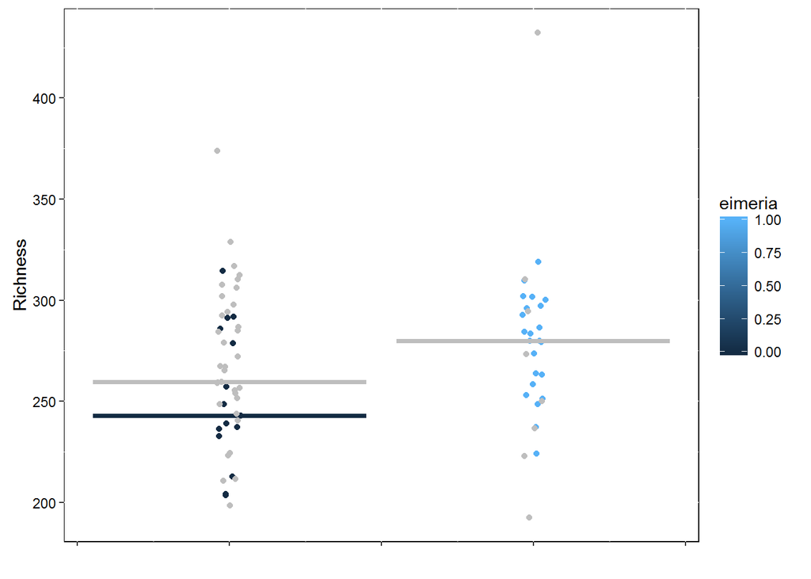

```r
multiple <- c("Anisha","Ari","Benja","Chewbacca","Cleopatra","Lasse","Laura","Lita","Napolean","Rachootin","Raleva") #mouse lemurs with multiple samples which were positive and negative for eimeria
md_eim <- subset(md, name %in% multiple)
md_noeim <- subset(md, !name %in% multiple)

ggplot()+
  geom_jitter(data=md_eim, aes(eimeria,sobs,color=eimeria),position=position_jitter(0.1))+
  stat_summary(data=md_eim, aes(eimeria,sobs,color=eimeria),fun.y=median, geom="crossbar", ymax=-100, ymin=-100)+
  geom_jitter(data=md_noeim, aes(eimeria,sobs),position=position_jitter(0.1),colour="grey")+
  stat_summary(data=md, aes(eimeria,sobs),fun.y=median, geom="crossbar", ymax=-100, ymin=-100,colour="grey")+
  labs(x="",y="Richness")+
  theme(axis.text.x=element_blank(),
        axis.text.y=element_text(colour="black"),
        panel.background=element_rect(fill="white", colour="black"),
        strip.background=element_blank())
```

And then Figure 1b

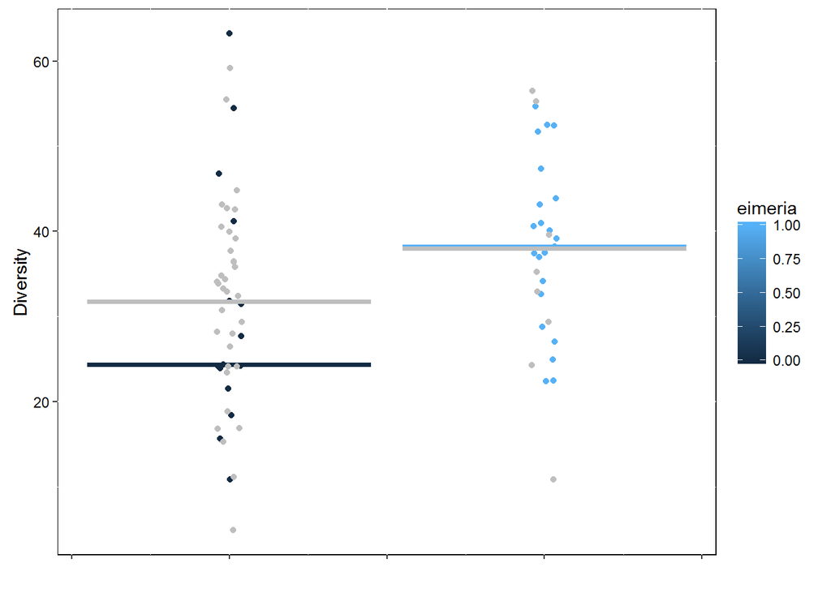

```r
ggplot()+
  geom_jitter(data=md_eim, aes(eimeria,invsimpson,color=eimeria),position=position_jitter(0.1))+
  stat_summary(data=md_eim, aes(eimeria,invsimpson,color=eimeria),fun.y=median, geom="crossbar", ymax=-100, ymin=-100)+
  geom_jitter(data=md_noeim, aes(eimeria,invsimpson),position=position_jitter(0.1),colour="grey")+
  stat_summary(data=md, aes(eimeria,invsimpson),fun.y=median, geom="crossbar", ymax=-100, ymin=-100,colour="grey")+
  labs(x="",y="Diversity")+
  theme(axis.text.x=element_blank(),
        axis.text.y=element_text(colour="black"),
        panel.background=element_rect(fill="white", colour="black"),
        strip.background=element_blank())
```

Then we move to dissimilarity matrices which were presented in the Appendix of the manuscript.

First we load them, and do some housekeeping.

```r
dist <- read.table(file = "yueclayton.dist",
                   skip = 1, row.names = 1)

dist <- dist[row.names(dist) %in% md$group,]
rownames(dist) <- gsub("^(.*)_16S", "\\1", rownames(dist))
o <- order(rownames(dist))
dist <- dist[o, o]
stopifnot(sum(rownames(dist) != rownames(md)) == 0)
yueclay <- dist
thetayc <- as.dist(dist)

dist <- read.table(file = "jaccard.dist",
                   skip = 1, row.names = 1)
dist <- dist[row.names(dist) %in% md$group,]
rownames(dist) <- gsub("^(.*)_16S", "\\1", rownames(dist))
o <- order(rownames(dist))
dist <- dist[o, o]
stopifnot(sum(rownames(dist) != rownames(md)) == 0)
jacc <- dist
jclass <- as.dist(dist)

dist <- read.table(file = "braycurtis.dist",
                   skip = 1, row.names = 1)
dist <- dist[row.names(dist) %in% md$group,]
rownames(dist) <- gsub("^(.*)_16S", "\\1", rownames(dist))
o <- order(rownames(dist))
dist <- dist[o, o]
stopifnot(sum(rownames(dist) != rownames(md)) == 0)
bray <- dist
braycurtis <- as.dist(dist)


dist <- read.table(file = "ochiai.dist",
                   skip = 1, row.names = 1)
dist <- dist[row.names(dist) %in% md$group,]
rownames(dist) <- gsub("^(.*)_16S", "\\1", rownames(dist))
o <- order(rownames(dist))
dist <- dist[o, o]
mdo = md [-30,]
stopifnot(sum(rownames(dist) != rownames(mdo)) == 0)
och <- dist
ochiai <- as.dist(dist)

md$week <- as.factor(md$week)
```

Next, we will do the permutational manovas.

```r
adonis(thetayc ~ md$age+md$cond+md$week+md$aggr+md$sex+md$site+md$nematode+md$hnana+md$hdiminuta+md$eimeria+md$ecto, strata = md$name, perm = 1000)
```

```
##
## Call:
## adonis(formula = thetayc ~ md$age + md$cond + md$week + md$aggr +      md$sex + md$site + md$nematode + md$hnana + md$hdiminuta +      md$eimeria + md$ecto, permutations = 1000, strata = md$name)
##
## Blocks:  strata
## Permutation: free
## Number of permutations: 1000
##
## Terms added sequentially (first to last)
##
##              Df SumsOfSqs MeanSqs F.Model      R2  Pr(>F)
## md$age        3    0.8933 0.29775 1.48871 0.05420 0.48551
## md$cond       1    0.2335 0.23352 1.16757 0.01417 0.41059
## md$week       3    0.4716 0.15719 0.78591 0.02861 0.95105
## md$aggr       1    0.1787 0.17871 0.89353 0.01084 0.59141
## md$sex        1    0.3456 0.34556 1.72774 0.02097 0.48052
## md$site       1    0.3248 0.32481 1.62401 0.01971 0.23676
## md$nematode   1    0.2043 0.20431 1.02153 0.01240 0.46354
## md$hnana      1    0.1885 0.18845 0.94223 0.01143 0.70729
## md$hdiminuta  1    0.2898 0.28982 1.44907 0.01759 0.25075
## md$eimeria    1    0.2265 0.22648 1.13234 0.01374 0.22178
## md$ecto       1    0.3240 0.32398 1.61986 0.01966 0.03097 *
## Residuals    64   12.8004 0.20001         0.77668
## Total        79   16.4809                 1.00000
## ---
## Signif. codes:  0 '***' 0.001 '**' 0.01 '*' 0.05 '.' 0.1 ' ' 1
```

```r
adonis(jclass ~ md$age+md$sex+md$site+md$nematode+md$hnana+md$week+md$hdiminuta+md$eimeria+md$ecto, strata=md$name, perm = 1000)
```

```
##
## Call:
## adonis(formula = jclass ~ md$age + md$sex + md$site + md$nematode +      md$hnana + md$week + md$hdiminuta + md$eimeria + md$ecto,      permutations = 1000, strata = md$name)
##
## Blocks:  strata
## Permutation: free
## Number of permutations: 1000
##
## Terms added sequentially (first to last)
##
##              Df SumsOfSqs MeanSqs F.Model      R2   Pr(>F)
## md$age        3    0.5767 0.19223 1.16658 0.04307 0.257742
## md$sex        1    0.2672 0.26724 1.62183 0.01996 0.257742
## md$site       1    0.2146 0.21459 1.30231 0.01603 0.257742
## md$nematode   1    0.1748 0.17483 1.06099 0.01306 0.693307
## md$hnana      1    0.1445 0.14447 0.87674 0.01079 0.745255
## md$week       3    0.5748 0.19160 1.16276 0.04293 0.069930 .
## md$hdiminuta  1    0.1991 0.19906 1.20806 0.01487 0.003996 **
## md$eimeria    1    0.1845 0.18450 1.11969 0.01378 0.265734
## md$ecto       1    0.1773 0.17730 1.07601 0.01324 0.288711
## Residuals    66   10.8753 0.16478         0.81227
## Total        79   13.3887                 1.00000
## ---
## Signif. codes:  0 '***' 0.001 '**' 0.01 '*' 0.05 '.' 0.1 ' ' 1
```

```r
adonis(braycurtis ~ md$seqbatch+md$age+md$sex+md$site+md$week+md$nematode+md$hnana+md$hdiminuta+md$eimeria+md$ecto, strata=md$name,perm = 1000)
```

```
##
## Call:
## adonis(formula = braycurtis ~ md$seqbatch + md$age + md$sex +      md$site + md$week + md$nematode + md$hnana + md$hdiminuta +      md$eimeria + md$ecto, permutations = 1000, strata = md$name)
##
## Blocks:  strata
## Permutation: free
## Number of permutations: 1000
##
## Terms added sequentially (first to last)
##
##              Df SumsOfSqs MeanSqs F.Model      R2  Pr(>F)
## md$seqbatch   1    0.4075 0.40749 2.80192 0.03363 0.01598 *
## md$age        3    0.5609 0.18698 1.28568 0.04630 0.89311
## md$sex        1    0.2626 0.26261 1.80571 0.02167 0.06194 .
## md$site       1    0.2337 0.23371 1.60699 0.01929 0.13986
## md$week       3    0.3005 0.10017 0.68873 0.02480 0.98701
## md$nematode   1    0.1431 0.14313 0.98414 0.01181 0.66533
## md$hnana      1    0.1097 0.10972 0.75443 0.00906 0.86014
## md$hdiminuta  1    0.2342 0.23424 1.61061 0.01933 0.01998 *
## md$eimeria    1    0.1699 0.16986 1.16795 0.01402 0.25674
## md$ecto       1    0.2406 0.24063 1.65454 0.01986 0.03197 *
## Residuals    65    9.4532 0.14543         0.78022
## Total        79   12.1160                 1.00000
## ---
## Signif. codes:  0 '***' 0.001 '**' 0.01 '*' 0.05 '.' 0.1 ' ' 1
```

```r
adonis(ochiai ~ mdo$week+mdo$age+mdo$sex+mdo$site+mdo$nematode+mdo$hnana+mdo$hdiminuta+mdo$eimeria+mdo$ecto,strata=mdo$name,perm = 1000)
```

```
##
## Call:
## adonis(formula = ochiai ~ mdo$week + mdo$age + mdo$sex + mdo$site +      mdo$nematode + mdo$hnana + mdo$hdiminuta + mdo$eimeria +      mdo$ecto, permutations = 1000, strata = mdo$name)
##
## Blocks:  strata
## Permutation: free
## Number of permutations: 1000
##
## Terms added sequentially (first to last)
##
##               Df SumsOfSqs  MeanSqs F.Model      R2 Pr(>F)
## mdo$week       1    0.0708 0.070831 0.38667 0.00512 0.9930
## mdo$age        3    0.4526 0.150872 0.82360 0.03272 0.7982
## mdo$sex        1    0.0919 0.091895 0.50165 0.00664 0.1838
## mdo$site       1    0.1177 0.117664 0.64232 0.00851 0.8861
## mdo$nematode   1    0.1696 0.169621 0.92596 0.01226 0.3417
## mdo$hnana      1    0.2009 0.200852 1.09644 0.01452 0.1878
## mdo$hdiminuta  1    0.1235 0.123469 0.67401 0.00892 0.9940
## mdo$eimeria    1    0.1677 0.167735 0.91566 0.01212 0.7033
## mdo$ecto       1    0.1665 0.166460 0.90870 0.01203 0.7612
## Residuals     67   12.2734 0.183185         0.88716
## Total         78   13.8346                  1.00000
```

```r
mod_yc <- metaMDS(thetayc)
```

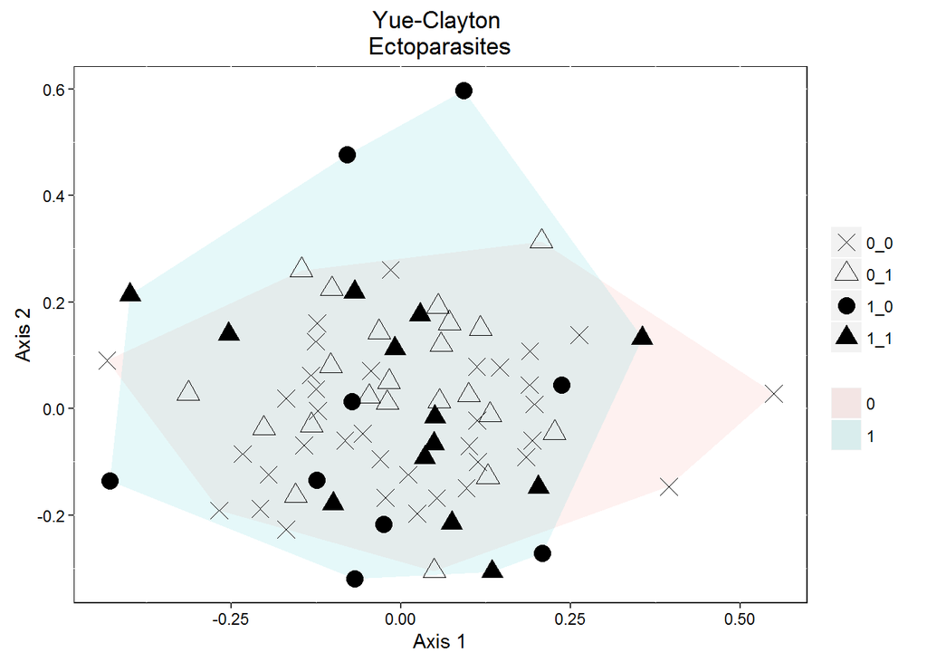

```r
MDS1 <- as.numeric(mod_yc$points[,1])
MDS2 <- as.numeric(mod_yc$points[,2])
MDS <- cbind(MDS1, MDS2)
row.names(MDS) <- row.names(md$points)
MDS_yc <- data.frame(MDS)
MDS_yc$ecto <- md$ecto
MDS_yc$comb <- paste(md$ecto,md$hdiminuta, sep="_")
MDS_yc_group <- as.factor(MDS_yc$ecto)

find_hull <- function(MDS_yc) MDS_yc[chull(MDS_yc$MDS1,MDS_yc$MDS2), ]
hulls <- ddply(MDS_yc, "MDS_yc_group", find_hull)
hulls$ecto <- as.factor(hulls$ecto)

ggplot(NULL, aes())+
  geom_polygon(data=hulls, aes(MDS1,MDS2,fill=factor(ecto)), alpha=0.1)+
  geom_point(data=MDS_yc, aes(MDS1,MDS2,shape=factor(comb)), alpha=1, size=4)+
  scale_shape_manual(values=c(4,2,16,17))+
  labs(title="Yue-Clayton \nEctoparasites", x="Axis 1",y="Axis 2")+
  theme(axis.text=element_text(colour="black"),
        legend.title=element_blank(),
        panel.background=element_rect(fill="white", colour="black"))
```

Then Jaccard.

```r
mod_j <- metaMDS(jclass)
```

```
## ... procrustes: rmse 0.0513638  max resid 0.2935744
## ... procrustes: rmse 0.04193533  max resid 0.3053515
## ... procrustes: rmse 0.0426962  max resid 0.3041597
```

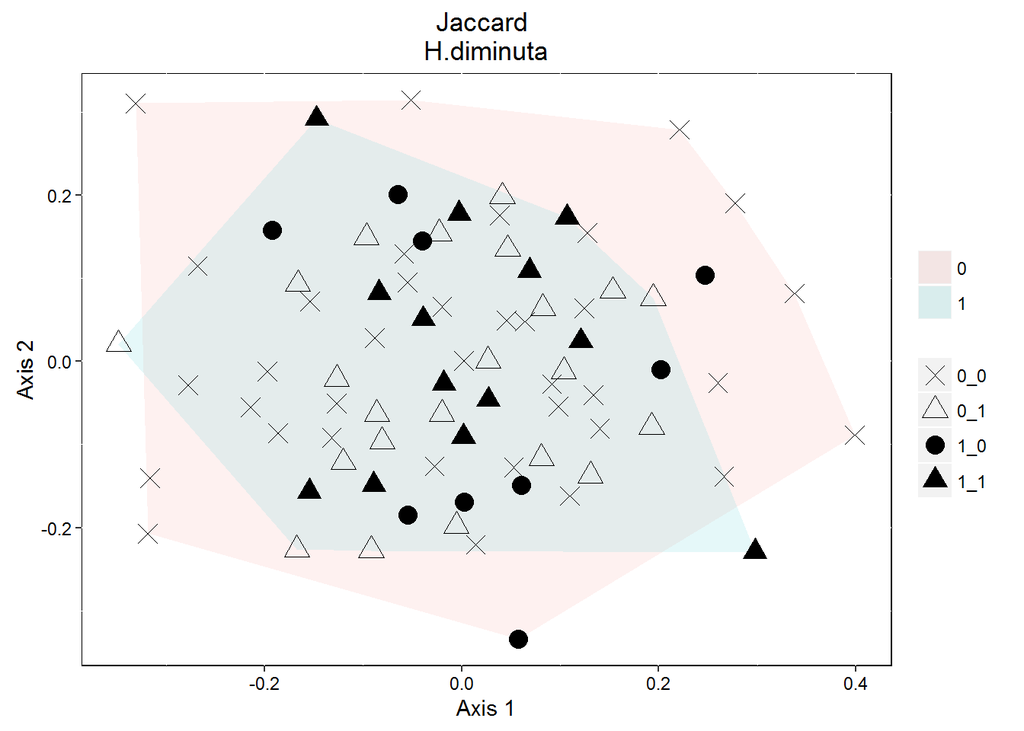

```r
MDS1 <- as.numeric(mod_j$points[,1])
MDS2 <- as.numeric(mod_j$points[,2])
MDS <- cbind(MDS1, MDS2)
row.names(MDS) <- row.names(md$points)
MDS_j <- data.frame(MDS)
MDS_j$hdiminuta <- md$hdiminuta
MDS_j$comb <- paste(md$ecto, md$hdiminuta, sep="_")
MDS_j_group <- as.factor(MDS_j$hdiminuta)

find_hull <- function(MDS_j) MDS_j[chull(MDS_j$MDS1,MDS_j$MDS2), ]
hulls <- ddply(MDS_j, "MDS_j_group", find_hull)
hulls$hdiminuta <- as.factor(hulls$hdiminuta)

ggplot(NULL, aes())+
  geom_polygon(data=hulls, aes(MDS1,MDS2,fill=factor(hdiminuta)), alpha=0.1)+
  geom_point(data=MDS_j, aes(MDS1,MDS2,shape=factor(comb)), alpha=1, size=4)+
  scale_shape_manual(values=c(4,2,16,17))+
  labs(title="Jaccard \nH.diminuta", x="Axis 1",y="Axis 2")+
  theme(axis.text=element_text(colour="black"),
        legend.title=element_blank(),
        panel.background=element_rect(fill="white", colour="black"))
```

Bray-Curtis:

```r
mod_bc <- metaMDS(braycurtis)
```

```
## ... procrustes: rmse 0.05858149  max resid 0.3919037
## ... procrustes: rmse 0.03108201  max resid 0.1583212
## ... procrustes: rmse 0.02661386  max resid 0.1768405
```

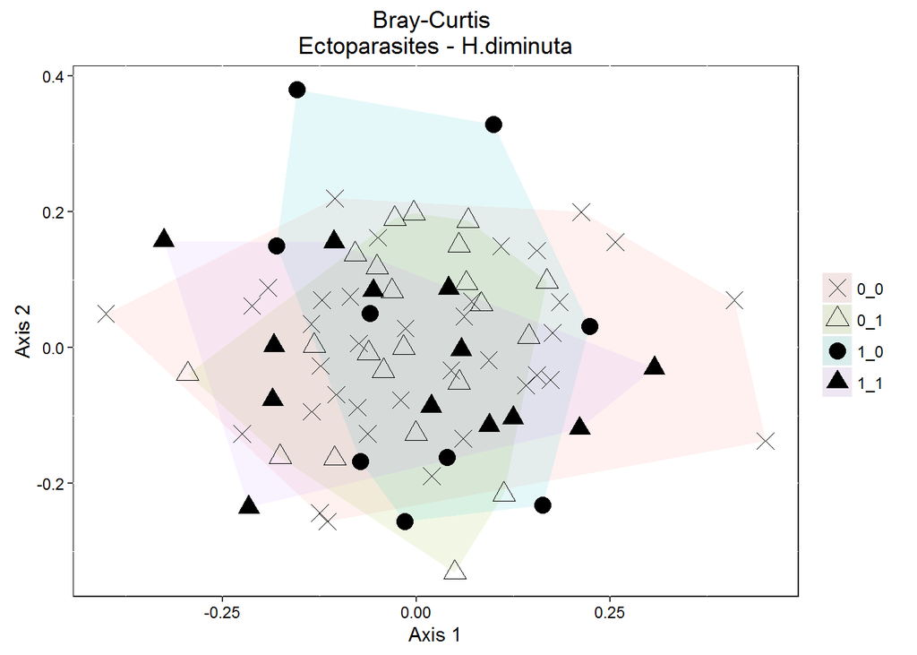

```r
MDS1 <- as.numeric(mod_bc$points[,1])
MDS2 <- as.numeric(mod_bc$points[,2])
MDS <- cbind(MDS1, MDS2)
row.names(MDS) <- row.names(md$points)
MDS_bc <- data.frame(MDS)
MDS_bc$factor <- paste(md$ecto,md$hdiminuta, sep="_")
MDS_bc_group <- as.factor(MDS_bc$factor)

find_hull <- function(MDS_bc) MDS_bc[chull(MDS_bc$MDS1,MDS_bc$MDS2), ]
hulls <- ddply(MDS_bc, "MDS_bc_group", find_hull)
hulls$factor <- as.factor(hulls$factor)

ggplot(NULL, aes(fill=factor(factor), shape=factor(factor)))+
  geom_polygon(data=hulls, aes(MDS1,MDS2),alpha=0.1)+
  geom_point(data=MDS_bc, aes(MDS1,MDS2), alpha=1, size=4)+
  scale_shape_manual(values=c(4,2,16,17))+
  labs(title="Bray-Curtis \nEctoparasites - H.diminuta", x="Axis 1",y="Axis 2")+
  theme(axis.text=element_text(colour="black"),
        legend.title=element_blank(),
        panel.background=element_rect(fill="white", colour="black"))
```

No need for Ochiai as there were no significant variables.

Next we go to group dispersion, which takes a bit of work because there is no ready-made replication within the #function. Thus we need take one sample per lemur and iterate this. First we create the needed iteration.

```r
names <- levels(droplevels(md$name))
name_nr <- length(names)
rows_with <- numeric(name_nr)
```

We define function resample() based on the documentation on sample()

```r
resample <- function(x, ...) x[sample.int(length(x), ...)]
```

Then we create null vectors and resample each distance matrix (5 parasites X 4 metrics):

```r
# creating vectors
nema_yc_iter=NULL
nema_bc_iter=NULL
nema_j_iter=NULL
nema_o_iter=NULL
hnana_yc_iter=NULL
hnana_bc_iter=NULL
hnana_j_iter=NULL
hnana_o_iter=NULL
hdimi_yc_iter=NULL
hdimi_bc_iter=NULL
hdimi_j_iter=NULL
hdimi_o_iter=NULL
eim_yc_iter=NULL
eim_bc_iter=NULL
eim_j_iter=NULL
eim_o_iter=NULL
ecto_yc_iter=NULL
ecto_bc_iter=NULL
ecto_j_iter=NULL
ecto_o_iter=NULL

#resampling for each distance matrix

for (i in 1:100){

  for(j in 1:name_nr){
    rows_with[j] <- resample(which(md$name == names[j]),1)
  }


  rows_with <- sort(rows_with)
  mdr <- md[rows_with,]

  thetayc2 <- as.dist(yueclay[rows_with,rows_with])
  betadisper_ycnem <- betadisper(thetayc2,mdr$nematode)
  anova(betadisper_ycnem)
  perm <- permutest(betadisper_ycnem, pairwise=TRUE)
  nema_yc_iter[i] = (perm$pairwise$observed[1]<0.05)

  betadisper_ychn <- betadisper(thetayc2,mdr$hnana)
  anova(betadisper_ychn)
  perm <- permutest(betadisper_ychn, pairwise=TRUE)
  hnana_yc_iter[i] = (perm$pairwise$observed[1]<0.05)

  betadisper_ychd <- betadisper(thetayc2,mdr$hdiminuta)
  anova(betadisper_ychd)
  perm <- permutest(betadisper_ychd, pairwise=TRUE)
  hdimi_yc_iter[i] = (perm$pairwise$observed[1]<0.05)

  betadisper_ycei <- betadisper(thetayc2,mdr$eimeria)
  anova(betadisper_ycei)
  perm <- permutest(betadisper_ycei, pairwise=TRUE)
  eim_yc_iter[i] = (perm$pairwise$observed[1]<0.05)

  betadisper_ycec <- betadisper(thetayc2,mdr$ecto)
  anova(betadisper_ycec)
  perm <- permutest(betadisper_ycec, pairwise=TRUE)
  ecto_yc_iter[i] = (perm$pairwise$observed[1]<0.05)

}

for (i in 1:100){

  for(j in 1:name_nr){
    rows_with[j] <- resample(which(md$name == names[j]),1)
  }


  rows_with <- sort(rows_with)
  mdr <- md[rows_with,]

  thetayc2 <- as.dist(bray[rows_with,rows_with])
  betadisper_bcnem <- betadisper(thetayc2,mdr$nematode)
  anova(betadisper_bcnem)
  perm <- permutest(betadisper_bcnem, pairwise=TRUE)
  nema_bc_iter[i] = (perm$pairwise$observed[1]<0.05)

  betadisper_bchn <- betadisper(thetayc2,mdr$hnana)
  anova(betadisper_bchn)
  perm <- permutest(betadisper_bchn, pairwise=TRUE)
  hnana_bc_iter[i] = (perm$pairwise$observed[1]<0.05)

  betadisper_bchd <- betadisper(thetayc2,mdr$hdiminuta)
  anova(betadisper_bchd)
  perm <- permutest(betadisper_bchd, pairwise=TRUE)
  hdimi_bc_iter[i] = (perm$pairwise$observed[1]<0.05)

  betadisper_bcei <- betadisper(thetayc2,mdr$eimeria)
  anova(betadisper_bcei)
  perm <- permutest(betadisper_bcei, pairwise=TRUE)
  eim_bc_iter[i] = (perm$pairwise$observed[1]<0.05)

  betadisper_bcec <- betadisper(thetayc2,mdr$ecto)
  anova(betadisper_bcec)
  perm <- permutest(betadisper_bcec, pairwise=TRUE)
  ecto_bc_iter[i] = (perm$pairwise$observed[1]<0.05)

}
for (i in 1:100){

  for(j in 1:name_nr){
    rows_with[j] <- resample(which(md$name == names[j]),1)
  }

  rows_with <- sort(rows_with)
  mdr <- md[rows_with,]

  thetayc2 <- as.dist(jacc[rows_with,rows_with])
  betadisper_jnem <- betadisper(thetayc2,mdr$nematode)
  anova(betadisper_jnem)
  perm <- permutest(betadisper_jnem, pairwise=TRUE)
  nema_j_iter[i] = (perm$pairwise$observed[1]<0.05)

  betadisper_jhn <- betadisper(thetayc2,mdr$hnana)
  anova(betadisper_jhn)
  perm <- permutest(betadisper_jhn, pairwise=TRUE)
  hnana_j_iter[i] = (perm$pairwise$observed[1]<0.05)

  betadisper_jhd <- betadisper(thetayc2,mdr$hdiminuta)
  anova(betadisper_jhd)
  perm <- permutest(betadisper_jhd, pairwise=TRUE)
  hdimi_j_iter[i] = (perm$pairwise$observed[1]<0.05)

  betadisper_jei <- betadisper(thetayc2,mdr$eimeria)
  anova(betadisper_jei)
  perm <- permutest(betadisper_jei, pairwise=TRUE)
  eim_j_iter[i] = (perm$pairwise$observed[1]<0.05)

  betadisper_jec <- betadisper(thetayc2,mdr$ecto)
  anova(betadisper_jec)
  perm <- permutest(betadisper_jec, pairwise=TRUE)
  ecto_j_iter[i] = (perm$pairwise$observed[1]<0.05)
}


for (i in 1:100){

  for(j in 1:name_nr){
    rows_with[j] <- resample(which(mdo$name == names[j]),1)
  }

  rows_with <- sort(rows_with)
  mdr <- mdo[rows_with,]

  thetayc2 <- as.dist(och[rows_with,rows_with])
  betadisper_onem <- betadisper(thetayc2,mdr$nematode)
  anova(betadisper_onem)
  perm <- permutest(betadisper_onem, pairwise=TRUE)
  nema_o_iter[i] = (perm$pairwise$observed[1]<0.05)

  betadisper_ohn <- betadisper(thetayc2,mdr$hnana)
  anova(betadisper_ohn)
  perm <- permutest(betadisper_ohn, pairwise=TRUE)
  hnana_o_iter[i] = (perm$pairwise$observed[1]<0.05)

  betadisper_ohd <- betadisper(thetayc2,mdr$hdiminuta)
  anova(betadisper_ohd)
  perm <- permutest(betadisper_ohd, pairwise=TRUE)
  hdimi_o_iter[i] = (perm$pairwise$observed[1]<0.05)

  betadisper_oei <- betadisper(thetayc2,mdr$eimeria)
  anova(betadisper_oei)
  perm <- permutest(betadisper_oei, pairwise=TRUE)
  eim_o_iter[i] = (perm$pairwise$observed[1]<0.05)

  betadisper_oec <- betadisper(thetayc2,mdr$ecto)
  anova(betadisper_oec)
  perm <- permutest(betadisper_oec, pairwise=TRUE)
  ecto_o_iter[i] = (perm$pairwise$observed[1]<0.05)

}
```

Then we calculate the positive samples:

```r
sum(hnana_bc_iter)
sum(hnana_j_iter)
sum(hnana_o_iter)
sum(hnana_yc_iter)

sum(hdimi_bc_iter)
sum(hdimi_j_iter)
sum(hdimi_o_iter)
sum(hdimi_yc_iter)

sum(nema_bc_iter)
sum(nema_j_iter)
sum(nema_o_iter)
sum(nema_yc_iter)

sum(eim_bc_iter)
sum(eim_j_iter)
sum(eim_o_iter)
sum(eim_yc_iter)

sum(ecto_bc_iter)
sum(ecto_j_iter)
sum(ecto_o_iter)
sum(ecto_yc_iter)
```

These were the results I got from my definite run:

Number of significant group dispersions with 100 iterations:

|  | Jaccard | Ochiai | Bray-Curtis | Yue-Clayton |
| --- | --- | --- | --- | --- |
| H. diminuta | 0 | 0 | 0 | 0 |
| H. nana | 0 | 0 | 0 | 0 |
| Ectos | 1 | 22 | 0 | 11 |
| Eimeria | 8 | 4 | 0 | 0 |
| Nematode | 0 | 11 | 4 | 10 |

Last - and least - the effect of new infections on similarities

```r
simi_par <- read.csv(file="interaction_similarity.csv", sep=";", dec=",")
simi_par$hnana <- as.factor(simi_par$hnana)
simi_par$hdiminuta <- as.factor(simi_par$hdiminuta)
simi_par$nematode <- as.factor(simi_par$nematode)
simi_par$ecto <- as.factor(simi_par$ecto)
simi_par$eimeria <- as.factor(simi_par$eimeria)

anova(lme(simil_jac ~ nematode+hnana+hdiminuta+eimeria+ecto+total+days, data=simi_par, random=~1|name))
```

```
##             numDF denDF   F-value p-value
## (Intercept)     1    10 2785.4773  <.0001
## nematode        2    10    1.1011  0.3697
## hnana           2    10    2.2942  0.1513
## hdiminuta       2    10    3.4297  0.0734
## eimeria         2    10    3.7642  0.0604
## ecto            3    10    1.4148  0.2954
## total           1    10    0.2145  0.6532
## days            1    10    8.3415  0.0162
```

```r
anova(lme(simil_the ~ nematode+hnana+hdiminuta+eimeria+ecto+total+days, data=simi_par, random=~1|name))
```

```
##             numDF denDF   F-value p-value
## (Intercept)     1    10 1106.5682  <.0001
## nematode        2    10    2.0448  0.1801
## hnana           2    10    6.8238  0.0135
## hdiminuta       2    10    2.8256  0.1065
## eimeria         2    10    3.0154  0.0945
## ecto            3    10    3.4839  0.0581
## total           1    10    0.5634  0.4702
## days            1    10    8.9589  0.0135
```